# R Notebook

### Goal

The growth of supermarkets in most cities is increasing and market competitions are also high , our data set is one of the historical sales of supermarket company which has recorded in 3 different branches for 3 months. Our main goal is to analyze the rating for the supermarkets branches

#### attributes:

Invoice id (Nominal): Computer generated sales slip invoice identification number. the possible values are unique id for each object containing 9 digits

Branch (Nominal): Branch of super center (3 branches are available identified by A, B and C).

City (Nominal): Location of supercenters the possibal values are Yangon, Naypyitaw, and Mandalay.

Customer type (Binary): Type of customers, recorded by Members for customers using member card and Normal for without member card.

Gender(Binary): Gender type of customer. the possible values are Female or male

Product line(Nominal): General item categorization groups - Electronic accessories, Fashion accessories, Food and beverages, Health and beauty, Home and lifestyle, Sports and travel.

Unit price(Numeric - ratio): Price of each product in $. the possible values are range from 10.08 to 99.96

Tax(Numeric - ratio): 5% tax fee for customer buying. the possible values are range from 0.5085 to 49.6500

Total(Numeric - Interval): Total price including tax. the possible values are range from 10.68 to 1042.65

Date(Ordinal): Date of purchase (Record available from January 2019 to March 2019)

Time(ordinal): Purchase time .the possible values between (10am to 9pm).

Payment(Nominal): Payment used by customer for purchase (3 methods are available – Cash, Credit card and Ewallet).

COGS(Numeric - Interval): Cost of goods sold. the possible values are range from 10.17 to 993.00

Gross margin percentage(Numeric - ratio): Gross margin percentage it has only one value 4.761905

Gross income(Numeric - ratio): Gross income is the total earnings or income from all sources before taxes.

Rating(ordinal): Customer stratification rating on their overall shopping experience (On a scale of 1 to 10).

Data set link:https://www.kaggle.com/datasets/aungpyaeap/supermarket-sales

we imported the dataset

```r
library(readxl)
dataset <- read.csv("C:/Users/shgab/OneDrive/سطح المكتب/csv.supermarketDataset.csv")
View(dataset)
```

Check nulls value, there is no nulls values

```r
sum(is.na(dataset))
```

```
[1] 0
```

install the libraries

```r
#install.packages("tidyverse")
library(tidyverse)
#install.packages("dplyr")
library(dplyr)
library(stringr)
#install.packages("outliers")
library(outliers)
#install.packages("ggplot2")
library(ggplot2)
```

Delete attribute from dataset because: 1-since every city has one branch then city attribute is a redundant value 2-The Tax and gross income are the same so the tax is a redundant value 3-This attribute contain the same values in all the rows

```r
dataset$City = NULL
dataset$Tax.5. = NULL
dataset$gross.margin.percentage = NULL
```

statistical Measures:

```r
summary(dataset)
```

```
  Invoice.ID           Branch          Customer.type         Gender          Product.line
 Length:1000        Length:1000        Length:1000        Length:1000        Length:1000
 Class :character   Class :character   Class :character   Class :character   Class :character
 Mode  :character   Mode  :character   Mode  :character   Mode  :character   Mode  :character



   Unit.price       Quantity         Total             Date               Time             Payment
 Min.   :10.08   Min.   : 1.00   Min.   :  10.68   Length:1000        Length:1000        Length:1000
 1st Qu.:32.88   1st Qu.: 3.00   1st Qu.: 124.42   Class :character   Class :character   Class :character
 Median :55.23   Median : 5.00   Median : 253.85   Mode  :character   Mode  :character   Mode  :character
 Mean   :55.67   Mean   : 5.51   Mean   : 322.97
 3rd Qu.:77.94   3rd Qu.: 8.00   3rd Qu.: 471.35
 Max.   :99.96   Max.   :10.00   Max.   :1042.65
      cogs         gross.income         Rating
 Min.   : 10.17   Min.   : 0.5085   Min.   : 4.000
 1st Qu.:118.50   1st Qu.: 5.9249   1st Qu.: 5.500
 Median :241.76   Median :12.0880   Median : 7.000
 Mean   :307.59   Mean   :15.3794   Mean   : 6.973
 3rd Qu.:448.90   3rd Qu.:22.4453   3rd Qu.: 8.500
 Max.   :993.00   Max.   :49.6500   Max.   :10.000
```

Create The Boxplot:

unit price boxplot

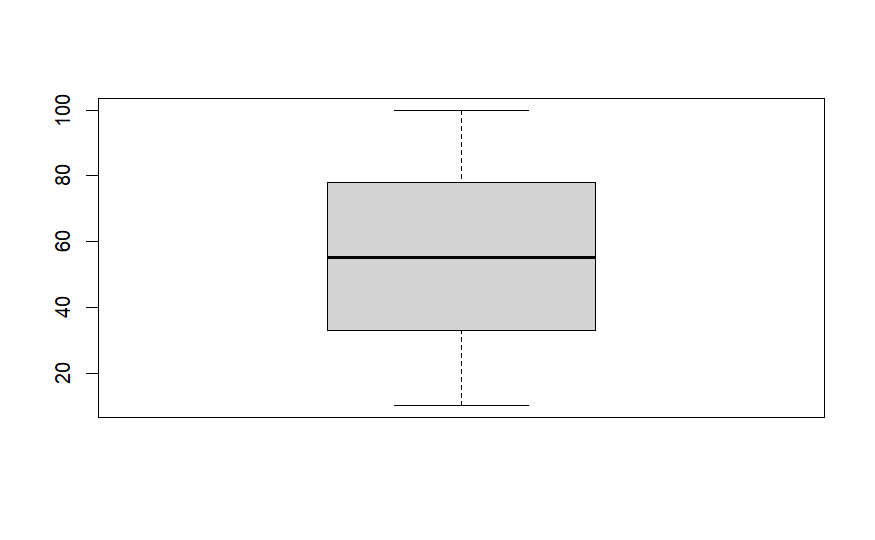

```r
boxplot(dataset$Unit.price)
```

The “Unit Price” boxplot shows that there are no outliers in the “Unit Price” attribute. We noticed that the average was close to 56, with the total unit price ranging from 10 to nearly 100 kyat

Quantity boxplot

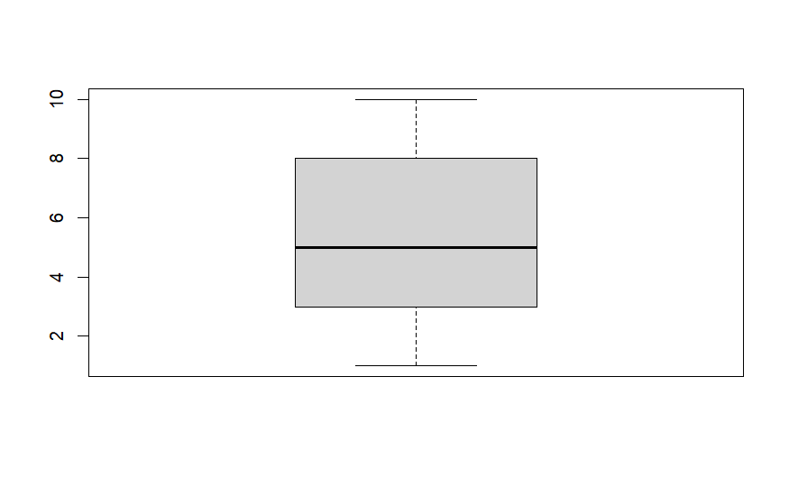

```r
 boxplot(dataset$Quantity)
```

The” Quantity” boxplot shows that there are no outliers in the quantity of this item. We find that the average value of the values is almost 6 and the total number is between 1 and 10

Total boxplot

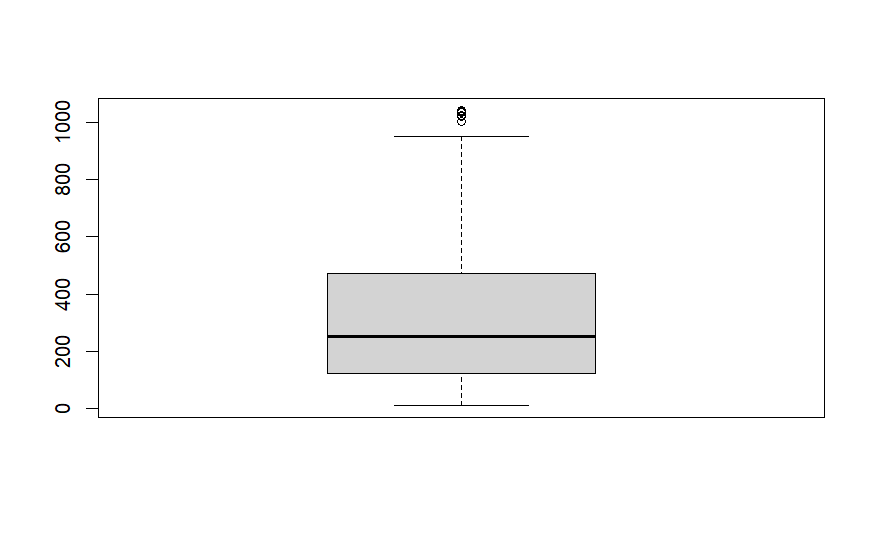

```r
boxplot(dataset$Total)
```

The “Total” boxplot shows that there are outliers that are close to each other and need to be removed during the preprocessing stage. We also notice that the mean of values is close to 320, with outliers existing almost above 900.

cogs boxplot

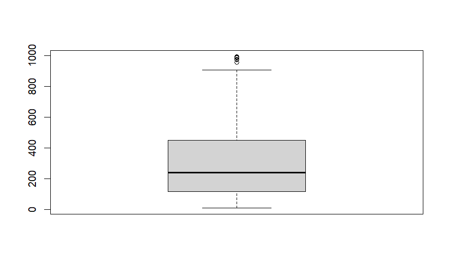

```r
boxplot(dataset$cogs)
```

The “Cogs” illustrates many outliers and the need for preprocessing. We also find that the mean is close to 300 and the outliers are almost over 900.

gross income boxplot

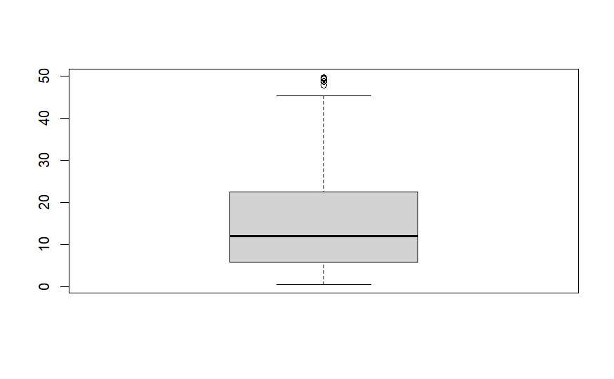

```r
boxplot(dataset$gross.income)
```

The ” Gross income ” boxplot shows many outliers that are very close to each other and needs to be smoothed to remove this noise.

We checked all the numbers to see if there were any outliers. Then, we took out the lines where we found the outliers to make a more accurate dataset that would help us get more accurate results later.

```r
#detict the outliers fot the Total
OutTotal = outlier(dataset$Total, logical =TRUE)
sum(OutTotal)
```

```
[1] 1
```

```r
Find_outlier = which(OutTotal ==TRUE, arr.ind = TRUE)
OutTotal
```

[output not shown]

[output cut: 44 more lines]

```r
Find_outlier
```

```
[1] 351
```

```r
#remove the  fot the Total
dataset= dataset[-Find_outlier,]
```

```r
#detict the outliers for the cogs
OutCogs = outlier(dataset$cogs, logical =TRUE)
sum(OutCogs)
```

```
[1] 1
```

```r
Find_outlier = which(OutCogs ==TRUE, arr.ind = TRUE)
OutCogs
```

[output not shown]

[output cut: 44 more lines]

```r
Find_outlier
```

```
[1] 168
```

```r
#remove the outlier for the cogs
dataset= dataset[-Find_outlier,]
```

```r
#detict the outliers for the gross income
OutGrossIncome = outlier(dataset$gross.income, logical =TRUE)
sum(OutGrossIncome)
```

```
[1] 1
```

```r
Find_outlier = which(OutGrossIncome ==TRUE, arr.ind = TRUE)
OutGrossIncome
```

[output not shown]

[output cut: 44 more lines]

```r
Find_outlier
```

```
[1] 556
```

```r
#remove the outlier for the gross income
dataset= dataset[-Find_outlier,]
```

```r
#detict the outliers the Quantity
OutQuantity = outlier(dataset$Quantity, logical =TRUE)
sum(OutQuantity)
```

```
[1] 116
```

```r
Find_outlier = which(OutQuantity ==TRUE, arr.ind = TRUE)
OutQuantity
```

[output not shown]

[output cut: 44 more lines]

```r
Find_outlier
```

```
  [1]   8  14  15  50  59  64  66  69  71  72  76  79  92  97 106 110 119 139 141 142 143 147 165 167 182 203
 [27] 207 234 251 263 267 269 276 278 279 290 294 314 349 355 356 367 386 390 392 409 421 428 445 456 457 460
 [53] 464 471 477 480 482 483 485 490 492 527 531 545 559 563 564 569 586 600 612 621 625 628 633 647 650 661
 [79] 668 672 676 685 690 697 700 725 733 735 744 750 756 758 759 790 795 807 809 826 827 836 851 870 878 880
[105] 885 887 904 907 930 940 956 968 986 989 991 994
```

```r
#remove the outlier the Quantity
dataset= dataset[-Find_outlier,]
```

```r
#detict the outliers for the unit price
OutUnitPrice = outlier(dataset$Unit.price, logical =TRUE)
sum(OutUnitPrice)
```

```
[1] 1
```

```r
Find_outlier = which(OutUnitPrice ==TRUE, arr.ind = TRUE)
OutUnitPrice
```

[output not shown]

[output cut: 37 more lines]

```r
Find_outlier
```

```
[1] 832
```

```r
#remove the outlier for the unit price
dataset= dataset[-Find_outlier,]
```

dataset after removing the outliers

```r
summary(dataset)
```

```
  Invoice.ID           Branch          Customer.type         Gender          Product.line
 Length:880         Length:880         Length:880         Length:880         Length:880
 Class :character   Class :character   Class :character   Class :character   Class :character
 Mode  :character   Mode  :character   Mode  :character   Mode  :character   Mode  :character



   Unit.price       Quantity         Total            Date               Time             Payment
 Min.   :10.13   Min.   :1.000   Min.   : 10.68   Length:880         Length:880         Length:880
 1st Qu.:32.85   1st Qu.:3.000   1st Qu.:103.81   Class :character   Class :character   Class :character
 Median :55.05   Median :5.000   Median :221.95   Mode  :character   Mode  :character   Mode  :character
 Mean   :55.68   Mean   :4.901   Mean   :287.46
 3rd Qu.:77.94   3rd Qu.:7.000   3rd Qu.:416.52
 Max.   :99.96   Max.   :9.000   Max.   :944.62
      cogs         gross.income         Rating
 Min.   : 10.17   Min.   : 0.5085   Min.   : 4.000
 1st Qu.: 98.87   1st Qu.: 4.9435   1st Qu.: 5.575
 Median :211.38   Median :10.5690   Median : 7.000
 Mean   :273.77   Mean   :13.6885   Mean   : 6.997
 3rd Qu.:396.69   3rd Qu.:19.8345   3rd Qu.: 8.500
 Max.   :899.64   Max.   :44.9820   Max.   :10.000
```

Histogram

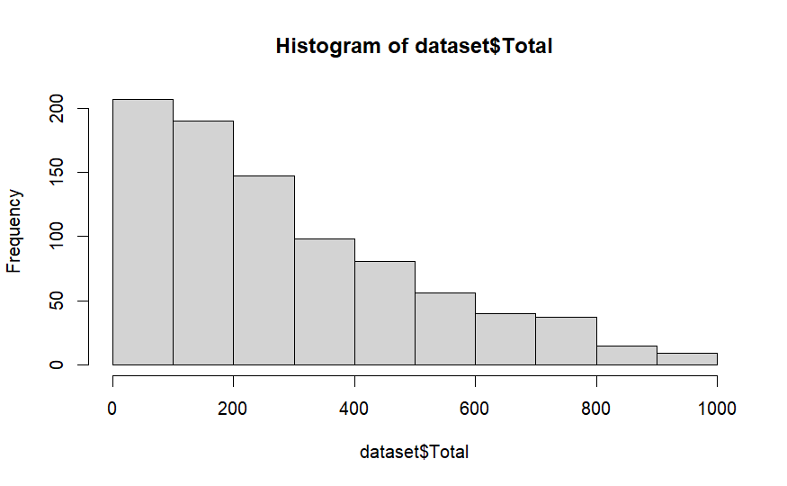

```r
hist(dataset$Total)
```

Scatter plot

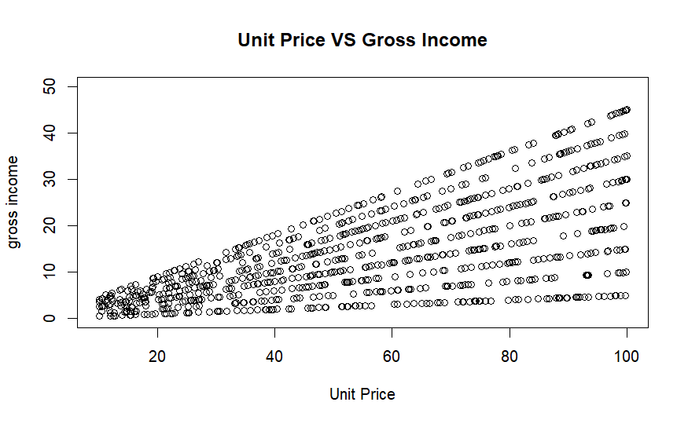

```r
plot(dataset$Unit.price, dataset$gross.income, main = "Unit Price VS Gross Income",
     xlab = "Unit Price", ylab = "gross income",
     xlim = c(10,100), ylim = c(0, 50))
```

convert the date which was character to be date type and extract the month from the dates by discretization

```r
dataset$Date <- format(as.Date(dataset$Date, format = "%m/%d/%Y"), "%m")
```

barplot for the date

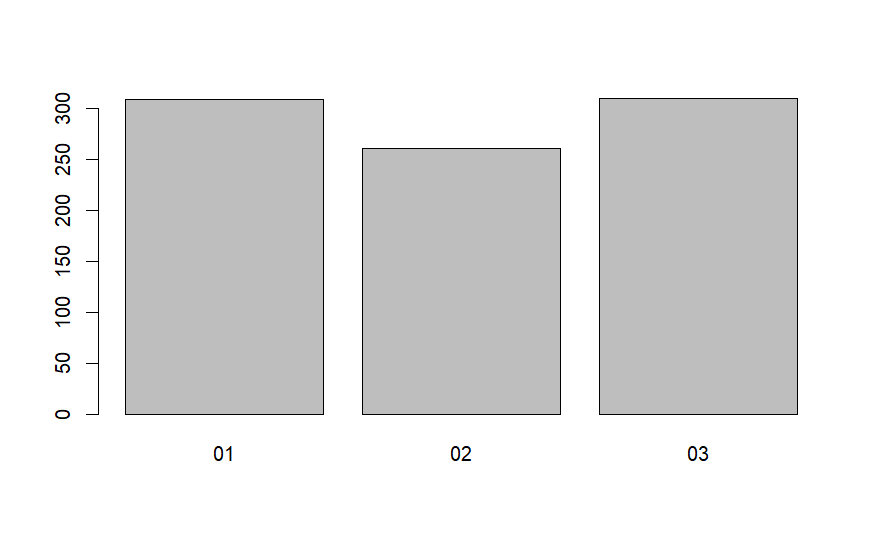

```r
barplot( table(dataset$Date) )
```

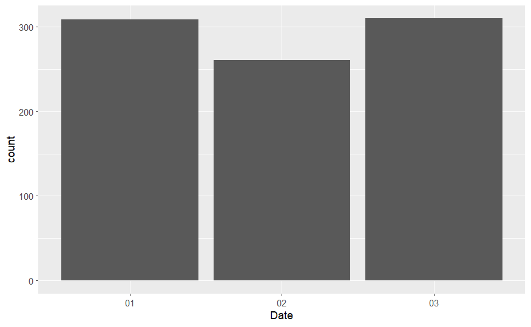

```r
dataset %>% ggplot(aes( x = Date)) + geom_bar()
```

The “date” after we extract the month from the date through discretization shows that the value in February is smaller than other months, while the values in January and March are almost the same.

incoding We encode the dataset to enable analysis because most machine learning and statistical analysis methods require numerical data as input and make the data much easier to understand.

```r
dataset$Branch=factor(dataset$Branch,
                      levels = c('A','B','C'),
                      labels = c(1 , 2 , 3))

dataset$Customer.type =factor(dataset$Customer.type,
                              levels = c('Normal','Member'),
                              labels = c(0 , 1))

dataset$Gender =factor(dataset$Gender,
                       levels = c('Female','Male'),
                       labels = c(0 , 1))
dataset$Product.line=factor(dataset$Product.line,
                            levels = c('Health and beauty','Electronic accessories','Home and lifestyle','Sports and travel','Food and beverages','Fashion accessories'),
                            labels = c(1 , 2, 3, 4,5,6))
dataset$Payment=factor(dataset$Payment,
                       levels = c('Ewallet','Cash','Credit card'),
                       labels = c(1 , 2 , 3))
```

normalization We do normalization for datasets to ensure that all features are on the same scale also Normalization makes data more consistent and aids in accurate comparisons and model convergence.

```r
normlize=function(x){return((x-min(x))/ (max(x)))}
dataset$Unit.price=normlize(dataset$Unit.price)
dataset$Total=normlize(dataset$Total)
dataset$cogs=normlize(dataset$cogs)
dataset$gross.income=normlize(dataset$gross.income)
```

we used substr to cut the time and depend only on the hours

```r
dataset$Time <- substr(dataset$Time, 1, 2)
```

##### We didn’t apply feature selection for our dataset because we need our attribute for the next phase